# ECS 158: Project #4 - GPU/CUDA

Joël Porquet

UC Davis, Fall 2018

# 1 Changelog

*Note that the specifications for this project are subject to change at anytime for additional clarification. Make sure to always refer to the **latest** version.*

- v2: CSIF pc41 should not be used
- v1: First publication

# 2 General information

- Due before **11:59 PM, Friday, December 7th, 2018**.
- You will be working with a partner for this project.
- The reference work environment is the CSIF.

## 2.1 Objectives of the project

The objectives of this programming project are:

- Understanding how image processing works, via the implementation of a Gaussian blur.
- Learning how to use the CUDA API in order to program a GPU.

## 2.2 Constraints

Your serial program must be written in C, be compiled with `gcc` and only use the standard functions provided by the [GNU C Library](https://www.gnu.org/software/libc/manual/) (aka `libc`).

Your CUDA-enabled program must be written in C/CUDA, be compiled with `nvcc` and only use the standard functions provided either by the libc or by the CUDA API.

Your program cannot be linked to any other external libraries, apart from the math library (`libm`).

Your source code should adopt a sane and consistent coding style and be properly commented when necessary.

Extra constraints are defined below. Not respecting these constraints will affect your score for the manual review.

All the timing measurements should be done on CSIF computers.

## 2.3 Assessment

Your grade for this assignment will be broken down in two scores:

- Auto-grading: ~90% of grade

  Running an auto-grading script that tests your program and checks the output against various inputs
- Manual review: ~10% of grade

  Quick manual review of your code. Includes submission, compilation, code style and quality of implementation.

# 3 Gaussian blur

A Gaussian blur is a 2-D convolution operator that is used to blur images in order to reduce detail and noise.

Technically, a Gaussian blur is represented as a matrix of weights, also called kernel or mask. The convolution is the process of adding each pixel of the image to its local neighbors, weighted by the matrix.

The example below shows how a 3x3 kernel matrix is applied to the pixel located at coordinate (1,1). In order to perform an entire 2-D convolution, such operation would need to be applied to each pixel of the original image.

Note that when apply the kernel matrix towards the edges or the corners, the “missing” pixels should be replaced by the nearest existing pixels (those directly on the edges, or corners).

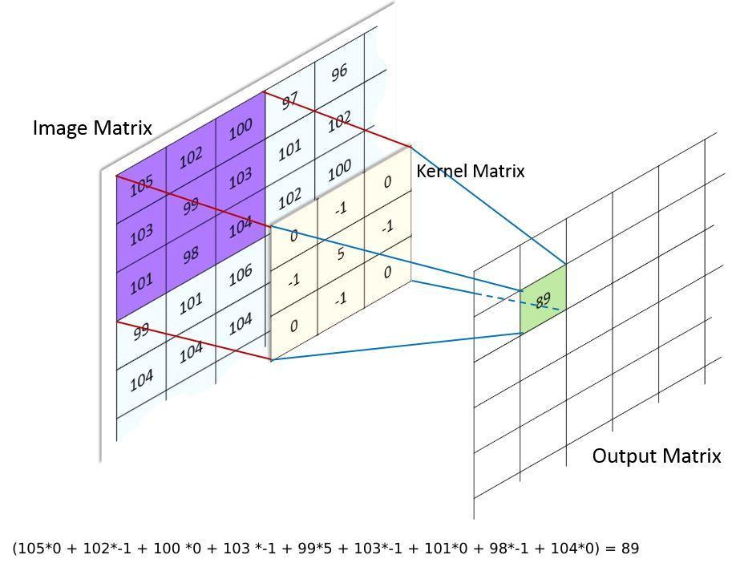

Convolution

Here is the Gaussian kernel matrix corresponding to a sigma of 1:

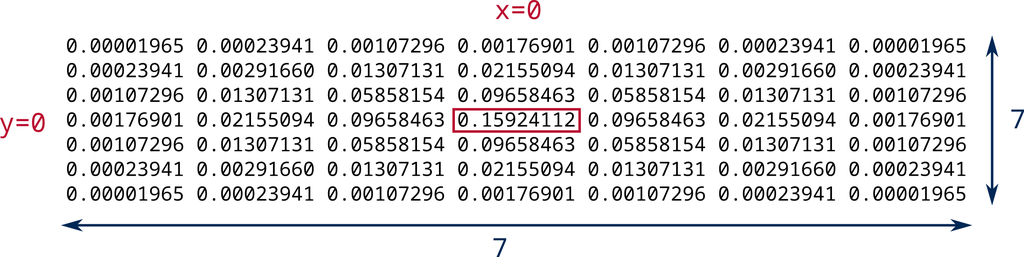

Kernel matrix for sigma of 1

As shown in the pictures below, increasing the sigma value increases the blurring of the input image:

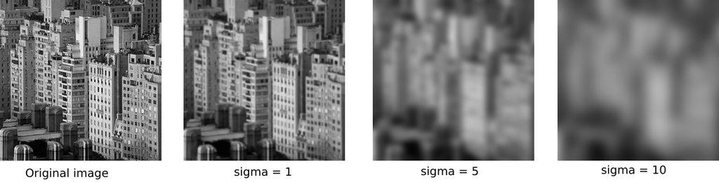

Blurring example

# 4 Program #1: serial implementation

## 4.1 Goal

The program should time the computational phase and display the running time in the console. Finally, it should save the post-processed image.

```
$ ./gaussian_blur_serial city_256.pgm city_256_1.pgm 1
Running time: 0.021506 secs
$ ./gaussian_blur_serial ucd_pavilion_15mp.pgm ucd_pavilion_15mp_5.pgm 5
Running time: 18.379832 secs
```

Any errors should be reported on the standard error stream, and the program should stop with an error code of 1.

```
$ ./gaussian_blur_serial
Usage: ./gaussian_blur_serial <input_file> <output_file> <sigma>
$ ./gaussian_blur_serial doesntexist doesntexist_1 1
Error: cannot open file doesntexist
$ ./gaussian_blur_serial <(echo -e "not PGM") toto_1 1
Error: invalid PGM information
$ ./gaussian_blur_serial <(echo -e "P5\n2\n") toto_1 1
Error: invalid PGM information
$ ./gaussian_blur_serial <(echo -e "P5\n2 2\n255\n") toto_1 1
Error: invalid PGM pixels
$ ./gaussian_blur_serial city_256.pgm city_256_1.pgm 45
Error: sigma value too big for image size
$ ./gaussian_blur_serial city_256.pgm city_256_1.pgm toto
Error: invalid sigma value
$ echo $?
1
```

A working example of the program can be found at `/home/cs158/public/p4/gaussian_blur_serial_reference`.

Multiple PGM images of various sizes (from 256x256 to 15MP) can also be found in `/home/cs158/public/p4/`. Please, do **not** submit any of these images in your bundle.

## 4.2 Additional information and constraints

- No need to use double-precision. Simple precision floating-point numbers should be enough and much faster (especially for the CUDA implementation).
- For this project, we will consider the *binary* version of the [`PGM` format](https://en.wikipedia.org/wiki/Netpbm_format#PGM_example).
  - The tag on the first line is `P5` (instead of `P2` for the ASCII version).
  - The next two lines are the same as in the ASCII version: dimensions of the image, and cutoff value (we can safely assume the cutoff will always be 255).
  - The rest of the file contain the pixel values, but in binary form. With a well-crafted `fread()` you can actually read the entire matrix of pixels directly in the image buffer. Same for generating the output, with `fwrite()`.
- When applying the kernel matrix on each pixel of the input image, make sure that you are staying without the bounds of the image. If pixels outside of the boundaries are needed, replace them by the nearest pixels of the corresponding edge.

# 5 Program #2: CUDA implementation

## 5.1 Goal

Write program `gaussian_blur_cuda.cu` that has the same behavior of the serial implementation but uses the GPU.

```
$ ./gaussian_blur_cuda city_256.pgm city_256_1.pgm 1
Running time: 0.082007 secs
$ ./gaussian_blur_cuda ucd_pavilion_15mp.pgm ucd_pavilion_15mp_5.pgm 5
Running time: 0.366971 secs
```

A working example of the program can be found at `/home/cs158/public/p4/gaussian_blur_cuda_reference`.

## 5.2 Additional information and constraints

- Not all the CSIF computers have a Nvidia GPU card. Only computers numbered from `pc21` to `pc60` have an *Nvidia GeForce GTX 960* card.
  - It is recommended not to use `pc41`, as it does not have the same GPU card as the other computer. It is equipped with an *Nvidia GeForce GTX 970* which is a better card.
  - Make sure that no one else is using the same CSIF computer when running your CUDA-enabled program, as the GPU cannot be shared between programs.
  - For some reason, the first run on a given computer is always very slow. You have to run your program multiple times to start getting stable running times.
- The convolution now has to be done by the GPU. To take advantage of the massively-parallel nature of the GPU, each CUDA thread should be in charge of computing only one pixel for the output image.
- Apart from adding the CUDA function, you should only change the function corresponding to the computational phase in your serial implementation (i.e., the one that is timed).
  - Instead, it should allocate and prepare memory for the GPU, setup the computation grid, and then instantiate your CUDA function to run onto the GPU. Finally, the memory should be properly disposed and the result copied back into the main memory.
- The compilation with `nvcc` is almost the same as with `gcc` except that you need to prefix all of the compiler flags with `-Xcompiler`:

  ```
  $ nvcc -Xcompiler -Wall -Xcompiler -Werror ... -o gaussian_blur_cuda gaussian_blur_cuda.cu -lm
  ```

# 6 Submission

Since we will use auto-grading scripts in order to test your program, make sure that it strictly follows the specified output format.

## 6.1 Content

You should submit the following files:

- `AUTHORS`: student ID of each partner, one entry per line. For example:

  ```
  $ cat AUTHORS
  00010001
  00010002
  $
  ```

- `Makefile`: a simple Makefile that compiles your source without any errors or warnings (on CSIF computers), and builds two executables: `gaussian_blur_serial` and `gaussian_blur_cuda`.
  - The compiler should be run with the options `-Wall -Werror -O2`.
  - There should also be a `clean` rule that removes generated files and puts the directory back in its original state.
- Your source code `gaussian_blur_serial.c` and `gaussian_blur_cuda.cu`, and any other relevant files.

Your submission should be empty of any clutter files (such as executable files, core dumps, backup files, and so on).

## 6.2 Git bundle

Your submission must be under the shape of a Git bundle. In your git repository, type in the following command (your work must be in the branch `master`):

```
$ git bundle create p4.bundle master
```

It should create the file `p4.bundle` that you will submit via `handin`.

Before submitting, **do make sure** that your bundle was properly been packaged by extracting it in another directory and verifying the log:

```
$ cd /path/to/tmp/dir
$ git clone /path/to/p4.bundle -b master p4
$ cd p4
$ ls
AUTHORS Makefile ...
$ git log
...
```

## 6.3 Handin

Your Git bundle, as created above, is to be submitted with `handin` from one of the CSIF computers by **only one person of your group**:

```
$ handin cs158 p4 p4.bundle
Submitting p4.bundle... ok
$
```

You can verify that the bundle has been properly submitted:

```
$ handin cs158 p4
The following input files have been received:
...
$
```

# 7 Academic integrity

You are expected to write this project **from scratch**, thus avoiding to use any existing source code available on the Internet. Asking someone else to write your code (e.g., on website such as Chegg.com) is not acceptable and will result in severe sanctions.

You must mention any sources that you have viewed to help you complete this assignment. All of the submissions will be compared with MOSS to determine if students have excessively collaborated, or have used the work of past students.

Any failure to respect the class rules, as explained above or in the syllabus, or the [UC Davis Code of Conduct](http://sja.ucdavis.edu/cac.html) will automatically result in the matter being transferred to Student Judicial Affairs.